## P2: Investage a dataset, Titanic

After following the course and looking at the project specification document I found it logical to use the data analysis phases to document how I approached this assignment. In practice it was not so straightforward. I came to the conclusion during the Wrangling phase that I had to drop a question and a lot of exploration was done as part of Question formulation and Wrangling.

Since I am not a big sports fan and know little about baseball rules, I chose the Titanic dataset.

# Question phase

I started out with a brief examination of the dataset, reading the description of the dataset on the Kaggle website and looking at information I could find on the web about the Titanic.

After reading the dataset in the dataframe titanic_df I used the functions titanic_df.head() and titanic_df.describe() for the dataframe and titanic_df.column_name.unique() for every column in the dataframe to get more insight in the data.

```python
#Examining the dataset - structure
import unicodecsv
import numpy as np
import pandas as pd
import seaborn as sns

#filename = 'https://d17h27t6h515a5.cloudfront.net/topher/2016/September/57e9a84c_titanic-data/titanic-data.csv'
filename = 'C:/Users/Marcel/Desktop/titanic-data.csv'
#filename = 'C:/titanic-data.csv'
titanic_df = pd.read_csv(filename)
titanic_df.head()
```

|  | PassengerId | Survived | Pclass | Name | Sex | Age | SibSp | Parch | Ticket | Fare | Cabin | Embarked |
| --- | --- | --- | --- | --- | --- | --- | --- | --- | --- | --- | --- | --- |
| 0 | 1 | 0 | 3 | Braund, Mr. Owen Harris | male | 22.0 | 1 | 0 | A/5 21171 | 7.2500 | NaN | S |
| 1 | 2 | 1 | 1 | Cumings, Mrs. John Bradley (Florence Briggs Th... | female | 38.0 | 1 | 0 | PC 17599 | 71.2833 | C85 | C |
| 2 | 3 | 1 | 3 | Heikkinen, Miss. Laina | female | 26.0 | 0 | 0 | STON/O2. 3101282 | 7.9250 | NaN | S |
| 3 | 4 | 1 | 1 | Futrelle, Mrs. Jacques Heath (Lily May Peel) | female | 35.0 | 1 | 0 | 113803 | 53.1000 | C123 | S |
| 4 | 5 | 0 | 3 | Allen, Mr. William Henry | male | 35.0 | 0 | 0 | 373450 | 8.0500 | NaN | S |

The following information found on the web I found interesting:

1. The letters in the Cabin field reference to the [decks](http://www.ultimatetitanic.com/facts-statistics/#.WBCogPp95aR), 9 in total (counting the orlop deck) the boat deck, A,B,C,D,E,F,G and below G boiler rooms.
2. The positions of the decks is that boat deck is on top (T-deck), followed by A until G and lowest is below G.
3. The ports of embarkation are in the following countries in the order of the [route](http://inthebookcase.blogspot.nl/2012/04/titanics-journey-is-underway.html): Southampton - England, Cherbourg - France, Queenstown - Ireland.

While examing information on the web, I read a story about a family that did not leave the Titanic because they were still looking for the baby of the family. What they did not know was that the nanny had already taken the baby in one of the lifeboats. The baby survived while the rest of the family drowned. There were also some women who refused to leave their husbands or other male relatives although they were offered room on the liveboats. These sad stories made me wonder what the influence of the size of the families has been: was there a stronger urge to stay together or a stronger sense of responsibility to save as much people as possible within the family. I know that this conclusion can not be made from the data, so I need to rephrase my question:

Question 1: What is the influence of the size of the family (in terms of the column 'Parch') on the survival rate of a person. I also want to see how this is impacted by age and sex; what has been the effect of 'Women and Children' first to the survival rates in general and was this different for families? For this I also need to come up with a definition of male children.

Question 2: Another thing that got me interested was the influence of the deck location of the cabins on the survival rate. The deck location of the cabins and the social status are probably related. That needs to be taken into account. But, I am doubtful if this question can be answered, since in the first five entries, I already see 3 null-values for Cabin.

# Wrangling phase

I did the following things to determine the quality of the data:

1. I examined which columns have null-values.
2. I checked every column for unique values.
3. I looked for outliers.
4. I splitted the Name field in lastname, title, firstname (sometimes it contains more information then firstname). I did this to examine if there is a correlation between the title and the age. The seperate Lastname field can be helpful when selecting/sorting on Lastname.
5. I solved the null-values for age and for embarked.
6. I decided not to select the deck identification from the cabin identification, because the cabin column contains a large number of null values for which I could not find other data in the dataset to solve this problem
7. I created more descriptive labels

```python
#Examining the dataset - which columns have null-values
titanic_df.isnull().sum()
```

```
PassengerId      0
Survived         0
Pclass           0
Name             0
Sex              0
Age            177
SibSp            0
Parch            0
Ticket           0
Fare             0
Cabin          687
Embarked         2
dtype: int64
```

```python
#Examining the dataset - example of investigating unique values for a column - Parch (Parents/Children)
#Replace parch for any other column name in the statement below to see the unique values for that column

sorted(titanic_df.Parch.unique())
```

```
[0, 1, 2, 3, 4, 5, 6]
```

```python
#Examining the dataset - min and max from describe to look for outliers
titanic_df.describe()
```

|  | PassengerId | Survived | Pclass | Age | SibSp | Parch | Fare |
| --- | --- | --- | --- | --- | --- | --- | --- |
| count | 891.000000 | 891.000000 | 891.000000 | 714.000000 | 891.000000 | 891.000000 | 891.000000 |
| mean | 446.000000 | 0.383838 | 2.308642 | 29.699118 | 0.523008 | 0.381594 | 32.204208 |
| std | 257.353842 | 0.486592 | 0.836071 | 14.526497 | 1.102743 | 0.806057 | 49.693429 |
| min | 1.000000 | 0.000000 | 1.000000 | 0.420000 | 0.000000 | 0.000000 | 0.000000 |
| 25% | 223.500000 | 0.000000 | 2.000000 | NaN | 0.000000 | 0.000000 | 7.910400 |
| 50% | 446.000000 | 0.000000 | 3.000000 | NaN | 0.000000 | 0.000000 | 14.454200 |
| 75% | 668.500000 | 1.000000 | 3.000000 | NaN | 1.000000 | 0.000000 | 31.000000 |
| max | 891.000000 | 1.000000 | 3.000000 | 80.000000 | 8.000000 | 6.000000 | 512.329200 |

```python
# Creating more descriptive labels

# Create Survival Label Column
titanic_df['Survival'] = titanic_df.Survived.map({0: 'Died', 1: 'Survived'})
titanic_df.Survival.head()

# Create Pclass Label Column
titanic_df['Class'] = titanic_df.Pclass.map({1 : 'First Class', 2 : 'Second Class', 3 : 'Third Class'})
titanic_df.Class.head()

# Create Embarked Labels Column
titanic_df['Ports'] = titanic_df.Embarked.map({'C' : 'Cherbourg', 'Q' : 'Queenstown', 'S' : 'Southampton'})
titanic_df.head()
```

|  | PassengerId | Survived | Pclass | Name | Sex | Age | SibSp | Parch | Ticket | Fare | Cabin | Embarked | Survival | Class | Ports |
| --- | --- | --- | --- | --- | --- | --- | --- | --- | --- | --- | --- | --- | --- | --- | --- |
| 0 | 1 | 0 | 3 | Braund, Mr. Owen Harris | male | 22.0 | 1 | 0 | A/5 21171 | 7.2500 | NaN | S | Died | Third Class | Southampton |
| 1 | 2 | 1 | 1 | Cumings, Mrs. John Bradley (Florence Briggs Th... | female | 38.0 | 1 | 0 | PC 17599 | 71.2833 | C85 | C | Survived | First Class | Cherbourg |
| 2 | 3 | 1 | 3 | Heikkinen, Miss. Laina | female | 26.0 | 0 | 0 | STON/O2. 3101282 | 7.9250 | NaN | S | Survived | Third Class | Southampton |
| 3 | 4 | 1 | 1 | Futrelle, Mrs. Jacques Heath (Lily May Peel) | female | 35.0 | 1 | 0 | 113803 | 53.1000 | C123 | S | Survived | First Class | Southampton |
| 4 | 5 | 0 | 3 | Allen, Mr. William Henry | male | 35.0 | 0 | 0 | 373450 | 8.0500 | NaN | S | Died | Third Class | Southampton |

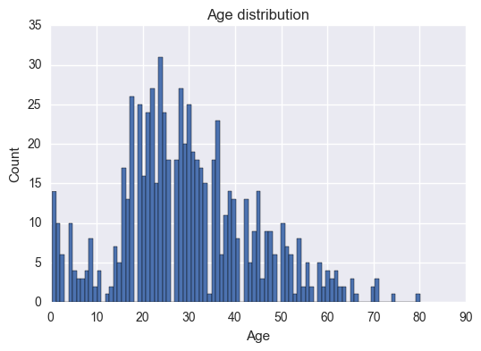

```python
#investigate single variable age
%matplotlib inline
import matplotlib.pyplot as plt

my_plot = titanic_df['Age'].plot(kind='hist',legend=None,title="Age distribution",bins=90)
my_plot.set_xlabel("Age")
my_plot.set_ylabel("Count")
```

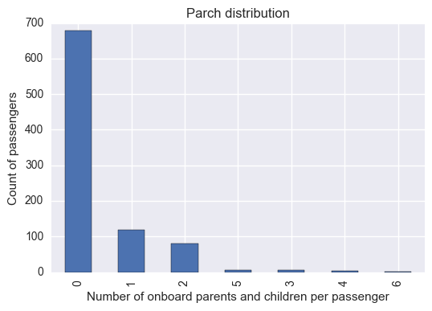

```python
#investigate single variable parch
%matplotlib inline
import matplotlib.pyplot as plt

my_plot=titanic_df.Parch.value_counts().plot(kind='bar', legend=None, title="Parch distribution")
my_plot.set_xlabel("Number of onboard parents and children per passenger")
my_plot.set_ylabel("Count of passengers")
plt.show()
```

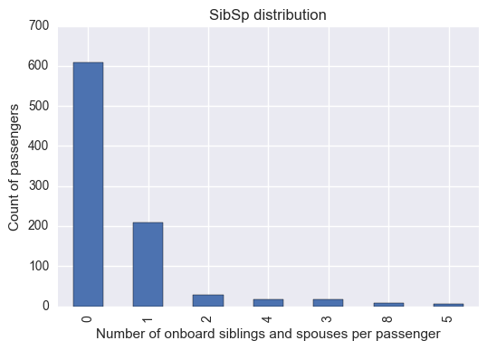

```python
#investigate single variable parch
%matplotlib inline
import matplotlib.pyplot as plt

my_plot=titanic_df.SibSp.value_counts().plot(kind='bar', legend=None, title="SibSp distribution")
my_plot.set_xlabel("Number of onboard siblings and spouses per passenger")
my_plot.set_ylabel("Count of passengers")
plt.show()
```

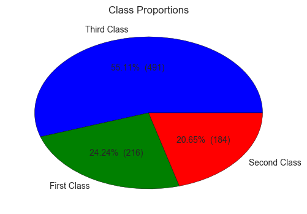

```python
#investigate single variable class
%matplotlib inline
import matplotlib.pyplot as plt

plt.title('Class Proportions')

def make_autopct(values):
    def my_autopct(pct):
        total = sum(values)
        val = int(round(pct*total/100.0))
        return '{p:.2f}%  ({v:d})'.format(p=pct,v=val)
    return my_autopct

plt.pie(titanic_df.Class.value_counts(), labels=titanic_df.Class.value_counts().index, autopct=make_autopct(titanic_df.Class.value_counts()))
plt.show()
```

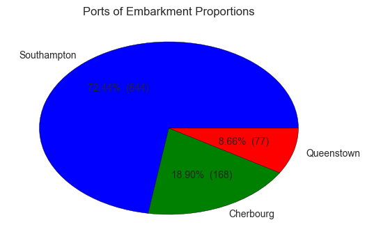

```python
#investigate single variable ports
%matplotlib inline
import matplotlib.pyplot as plt

plt.title('Ports of Embarkment Proportions')

plt.pie(titanic_df.Ports.value_counts(), labels=titanic_df.Ports.value_counts().index, autopct=make_autopct(titanic_df.Ports.value_counts()))
plt.show()
```

## Conclusions after investigation of data quality

```python
#Splitting the name field in Lastname, Title and Firstname (remainder)

titanic_df['Lastname'] = titanic_df.Name.str.split(',').str[0]
titanic_df['Remaindername'] = titanic_df.Name.str.split(',').str[1]
titanic_df['Remaindername']=titanic_df['Remaindername'].str.strip()

titanic_df['Title'] = titanic_df.Remaindername.str.split('.').str[0]
titanic_df['Firstname'] = titanic_df.Remaindername.str.split('.').str[1]

del titanic_df['Remaindername']
titanic_df.head()
```

|  | PassengerId | Survived | Pclass | Name | Sex | Age | SibSp | Parch | Ticket | Fare | Cabin | Embarked | Survival | Class | Ports | Lastname | Title | Firstname |
| --- | --- | --- | --- | --- | --- | --- | --- | --- | --- | --- | --- | --- | --- | --- | --- | --- | --- | --- |
| 0 | 1 | 0 | 3 | Braund, Mr. Owen Harris | male | 22.0 | 1 | 0 | A/5 21171 | 7.2500 | NaN | S | Died | Third Class | Southampton | Braund | Mr | Owen Harris |
| 1 | 2 | 1 | 1 | Cumings, Mrs. John Bradley (Florence Briggs Th... | female | 38.0 | 1 | 0 | PC 17599 | 71.2833 | C85 | C | Survived | First Class | Cherbourg | Cumings | Mrs | John Bradley (Florence Briggs Thayer) |
| 2 | 3 | 1 | 3 | Heikkinen, Miss. Laina | female | 26.0 | 0 | 0 | STON/O2. 3101282 | 7.9250 | NaN | S | Survived | Third Class | Southampton | Heikkinen | Miss | Laina |
| 3 | 4 | 1 | 1 | Futrelle, Mrs. Jacques Heath (Lily May Peel) | female | 35.0 | 1 | 0 | 113803 | 53.1000 | C123 | S | Survived | First Class | Southampton | Futrelle | Mrs | Jacques Heath (Lily May Peel) |
| 4 | 5 | 0 | 3 | Allen, Mr. William Henry | male | 35.0 | 0 | 0 | 373450 | 8.0500 | NaN | S | Died | Third Class | Southampton | Allen | Mr | William Henry |

```python
# examine mean age per title, sex
titanic_df.groupby(['Title','Sex'])['Age'].mean()
```

```
Title         Sex
Capt          male      70.000000
Col           male      58.000000
Don           male      40.000000
Dr            female    49.000000
              male      40.600000
Jonkheer      male      38.000000
Lady          female    48.000000
Major         male      48.500000
Master        male       4.574167
Miss          female    21.773973
Mlle          female    24.000000
Mme           female    24.000000
Mr            male      32.368090
Mrs           female    35.898148
Ms            female    28.000000
Rev           male      43.166667
Sir           male      49.000000
the Countess  female    33.000000
Name: Age, dtype: float64
```

```python
# examine standard deviation per title, sex
titanic_df.groupby(['Title','Sex'])['Age'].std()
```

```
Title         Sex
Capt          male            NaN
Col           male       2.828427
Don           male            NaN
Dr            female          NaN
              male      12.876335
Jonkheer      male            NaN
Lady          female          NaN
Major         male       4.949747
Master        male       3.619872
Miss          female    12.990292
Mlle          female     0.000000
Mme           female          NaN
Mr            male      12.708793
Mrs           female    11.433628
Ms            female          NaN
Rev           male      13.136463
Sir           male            NaN
the Countess  female          NaN
Name: Age, dtype: float64
```

```python
# examine number of passengers per title, sex
titanic_df.groupby(['Title', 'Sex'])['PassengerId'].count()
```

```
Title         Sex
Capt          male        1
Col           male        2
Don           male        1
Dr            female      1
              male        6
Jonkheer      male        1
Lady          female      1
Major         male        2
Master        male       40
Miss          female    182
Mlle          female      2
Mme           female      1
Mr            male      517
Mrs           female    125
Ms            female      1
Rev           male        6
Sir           male        1
the Countess  female      1
Name: PassengerId, dtype: int64
```

With exception of the Dr title (probably Doctor) every title is only used by one of the sexes. There is one female Dr and there are six male Dr. The majority of the titles is used once or few times. The titles Master, Miss, Mr and Mrs are used by the 97% of the passengers. These four titles have standard deviations around 12 with exception of Master, which has a very low standard deviation of 3.62. This is logical; based on this standard deviation in combination with the mean of 4.57, my conclusion is that the Master title was given to males who were not considered adults in that time. The maximum age found for Master is 12. The Mr title is used for the older males. The average age of a Miss is 21.77 and of a Mrs 35.90, making it two distinctly different groups.

Based on this information, I find it logical to determine a missing age on the mean of the age from everybody with the same title.

```python
# determine the average age for every title
mean_age_per_title=titanic_df.groupby('Title')['Age'].mean().reset_index()
mean_age_per_title.columns = ['Title', 'Average_age']
mean_age_per_title
```

|  | Title | Average_age |
| --- | --- | --- |
| 0 | Capt | 70.000000 |
| 1 | Col | 58.000000 |
| 2 | Don | 40.000000 |
| 3 | Dr | 42.000000 |
| 4 | Jonkheer | 38.000000 |
| 5 | Lady | 48.000000 |
| 6 | Major | 48.500000 |
| 7 | Master | 4.574167 |
| 8 | Miss | 21.773973 |
| 9 | Mlle | 24.000000 |
| 10 | Mme | 24.000000 |
| 11 | Mr | 32.368090 |
| 12 | Mrs | 35.898148 |
| 13 | Ms | 28.000000 |
| 14 | Rev | 43.166667 |
| 15 | Sir | 49.000000 |
| 16 | the Countess | 33.000000 |

```python
# apply the average age per title for every passenger where the age is not known
titanic_adjust_df=titanic_df.merge(mean_age_per_title,on='Title', how='left')
titanic_adjust_df.Age.fillna(titanic_adjust_df.Average_age, inplace=True)
del titanic_adjust_df['Average_age']
titanic_adjust_df.sort('Pclass')
```

|  | PassengerId | Survived | Pclass | Name | Sex | Age | SibSp | Parch | Ticket | Fare | Cabin | Embarked | Survival | Class | Ports | Lastname | Title | Firstname |
| --- | --- | --- | --- | --- | --- | --- | --- | --- | --- | --- | --- | --- | --- | --- | --- | --- | --- | --- |
| 445 | 446 | 1 | 1 | Dodge, Master. Washington | male | 4.000000 | 0 | 2 | 33638 | 81.8583 | A34 | S | Survived | First Class | Southampton | Dodge | Master | Washington |
| 310 | 311 | 1 | 1 | Hays, Miss. Margaret Bechstein | female | 24.000000 | 0 | 0 | 11767 | 83.1583 | C54 | C | Survived | First Class | Cherbourg | Hays | Miss | Margaret Bechstein |
| 309 | 310 | 1 | 1 | Francatelli, Miss. Laura Mabel | female | 30.000000 | 0 | 0 | PC 17485 | 56.9292 | E36 | C | Survived | First Class | Cherbourg | Francatelli | Miss | Laura Mabel |
| 307 | 308 | 1 | 1 | Penasco y Castellana, Mrs. Victor de Satode (M... | female | 17.000000 | 1 | 0 | PC 17758 | 108.9000 | C65 | C | Survived | First Class | Cherbourg | Penasco y Castellana | Mrs | Victor de Satode (Maria Josefa Perez de Soto ... |
| 306 | 307 | 1 | 1 | Fleming, Miss. Margaret | female | 21.773973 | 0 | 0 | 17421 | 110.8833 | NaN | C | Survived | First Class | Cherbourg | Fleming | Miss | Margaret |
| 305 | 306 | 1 | 1 | Allison, Master. Hudson Trevor | male | 0.920000 | 1 | 2 | 113781 | 151.5500 | C22 C26 | S | Survived | First Class | Southampton | Allison | Master | Hudson Trevor |
| 710 | 711 | 1 | 1 | Mayne, Mlle. Berthe Antonine ("Mrs de Villiers") | female | 24.000000 | 0 | 0 | PC 17482 | 49.5042 | C90 | C | Survived | First Class | Cherbourg | Mayne | Mlle | Berthe Antonine ("Mrs de Villiers") |
| 711 | 712 | 0 | 1 | Klaber, Mr. Herman | male | 32.368090 | 0 | 0 | 113028 | 26.5500 | C124 | S | Died | First Class | Southampton | Klaber | Mr | Herman |
| 311 | 312 | 1 | 1 | Ryerson, Miss. Emily Borie | female | 18.000000 | 2 | 2 | PC 17608 | 262.3750 | B57 B59 B63 B66 | C | Survived | First Class | Cherbourg | Ryerson | Miss | Emily Borie |
| 712 | 713 | 1 | 1 | Taylor, Mr. Elmer Zebley | male | 48.000000 | 1 | 0 | 19996 | 52.0000 | C126 | S | Survived | First Class | Southampton | Taylor | Mr | Elmer Zebley |
| 298 | 299 | 1 | 1 | Saalfeld, Mr. Adolphe | male | 32.368090 | 0 | 0 | 19988 | 30.5000 | C106 | S | Survived | First Class | Southampton | Saalfeld | Mr | Adolphe |
| 297 | 298 | 0 | 1 | Allison, Miss. Helen Loraine | female | 2.000000 | 1 | 2 | 113781 | 151.5500 | C22 C26 | S | Died | First Class | Southampton | Allison | Miss | Helen Loraine |
| 295 | 296 | 0 | 1 | Lewy, Mr. Ervin G | male | 32.368090 | 0 | 0 | PC 17612 | 27.7208 | NaN | C | Died | First Class | Cherbourg | Lewy | Mr | Ervin G |
| 716 | 717 | 1 | 1 | Endres, Miss. Caroline Louise | female | 38.000000 | 0 | 0 | PC 17757 | 227.5250 | C45 | C | Survived | First Class | Cherbourg | Endres | Miss | Caroline Louise |
| 291 | 292 | 1 | 1 | Bishop, Mrs. Dickinson H (Helen Walton) | female | 19.000000 | 1 | 0 | 11967 | 91.0792 | B49 | C | Survived | First Class | Cherbourg | Bishop | Mrs | Dickinson H (Helen Walton) |
| 290 | 291 | 1 | 1 | Barber, Miss. Ellen "Nellie" | female | 26.000000 | 0 | 0 | 19877 | 78.8500 | NaN | S | Survived | First Class | Southampton | Barber | Miss | Ellen "Nellie" |
| 571 | 572 | 1 | 1 | Appleton, Mrs. Edward Dale (Charlotte Lamson) | female | 53.000000 | 2 | 0 | 11769 | 51.4792 | C101 | S | Survived | First Class | Southampton | Appleton | Mrs | Edward Dale (Charlotte Lamson) |
| 299 | 300 | 1 | 1 | Baxter, Mrs. James (Helene DeLaudeniere Chaput) | female | 50.000000 | 0 | 1 | PC 17558 | 247.5208 | B58 B60 | C | Survived | First Class | Cherbourg | Baxter | Mrs | James (Helene DeLaudeniere Chaput) |
| 284 | 285 | 0 | 1 | Smith, Mr. Richard William | male | 32.368090 | 0 | 0 | 113056 | 26.0000 | A19 | S | Died | First Class | Southampton | Smith | Mr | Richard William |
| 708 | 709 | 1 | 1 | Cleaver, Miss. Alice | female | 22.000000 | 0 | 0 | 113781 | 151.5500 | NaN | S | Survived | First Class | Southampton | Cleaver | Miss | Alice |
| 319 | 320 | 1 | 1 | Spedden, Mrs. Frederic Oakley (Margaretta Corn... | female | 40.000000 | 1 | 1 | 16966 | 134.5000 | E34 | C | Survived | First Class | Cherbourg | Spedden | Mrs | Frederic Oakley (Margaretta Corning Stone) |
| 356 | 357 | 1 | 1 | Bowerman, Miss. Elsie Edith | female | 22.000000 | 0 | 1 | 113505 | 55.0000 | E33 | S | Survived | First Class | Southampton | Bowerman | Miss | Elsie Edith |
| 694 | 695 | 0 | 1 | Weir, Col. John | male | 60.000000 | 0 | 0 | 113800 | 26.5500 | NaN | S | Died | First Class | Southampton | Weir | Col | John |
| 351 | 352 | 0 | 1 | Williams-Lambert, Mr. Fletcher Fellows | male | 32.368090 | 0 | 0 | 113510 | 35.0000 | C128 | S | Died | First Class | Southampton | Williams-Lambert | Mr | Fletcher Fellows |
| 698 | 699 | 0 | 1 | Thayer, Mr. John Borland | male | 49.000000 | 1 | 1 | 17421 | 110.8833 | C68 | C | Died | First Class | Cherbourg | Thayer | Mr | John Borland |
| 341 | 342 | 1 | 1 | Fortune, Miss. Alice Elizabeth | female | 24.000000 | 3 | 2 | 19950 | 263.0000 | C23 C25 C27 | S | Survived | First Class | Southampton | Fortune | Miss | Alice Elizabeth |
| 339 | 340 | 0 | 1 | Blackwell, Mr. Stephen Weart | male | 45.000000 | 0 | 0 | 113784 | 35.5000 | T | S | Died | First Class | Southampton | Blackwell | Mr | Stephen Weart |
| 337 | 338 | 1 | 1 | Burns, Miss. Elizabeth Margaret | female | 41.000000 | 0 | 0 | 16966 | 134.5000 | E40 | C | Survived | First Class | Cherbourg | Burns | Miss | Elizabeth Margaret |
| 318 | 319 | 1 | 1 | Wick, Miss. Mary Natalie | female | 31.000000 | 0 | 2 | 36928 | 164.8667 | C7 | S | Survived | First Class | Southampton | Wick | Miss | Mary Natalie |
| 336 | 337 | 0 | 1 | Pears, Mr. Thomas Clinton | male | 29.000000 | 1 | 0 | 113776 | 66.6000 | C2 | S | Died | First Class | Southampton | Pears | Mr | Thomas Clinton |
| ... | ... | ... | ... | ... | ... | ... | ... | ... | ... | ... | ... | ... | ... | ... | ... | ... | ... | ... |
| 403 | 404 | 0 | 3 | Hakkarainen, Mr. Pekka Pietari | male | 28.000000 | 1 | 0 | STON/O2. 3101279 | 15.8500 | NaN | S | Died | Third Class | Southampton | Hakkarainen | Mr | Pekka Pietari |
| 406 | 407 | 0 | 3 | Widegren, Mr. Carl/Charles Peter | male | 51.000000 | 0 | 0 | 347064 | 7.7500 | NaN | S | Died | Third Class | Southampton | Widegren | Mr | Carl/Charles Peter |
| 408 | 409 | 0 | 3 | Birkeland, Mr. Hans Martin Monsen | male | 21.000000 | 0 | 0 | 312992 | 7.7750 | NaN | S | Died | Third Class | Southampton | Birkeland | Mr | Hans Martin Monsen |
| 409 | 410 | 0 | 3 | Lefebre, Miss. Ida | female | 21.773973 | 3 | 1 | 4133 | 25.4667 | NaN | S | Died | Third Class | Southampton | Lefebre | Miss | Ida |
| 410 | 411 | 0 | 3 | Sdycoff, Mr. Todor | male | 32.368090 | 0 | 0 | 349222 | 7.8958 | NaN | S | Died | Third Class | Southampton | Sdycoff | Mr | Todor |
| 411 | 412 | 0 | 3 | Hart, Mr. Henry | male | 32.368090 | 0 | 0 | 394140 | 6.8583 | NaN | Q | Died | Third Class | Queenstown | Hart | Mr | Henry |
| 414 | 415 | 1 | 3 | Sundman, Mr. Johan Julian | male | 44.000000 | 0 | 0 | STON/O 2. 3101269 | 7.9250 | NaN | S | Survived | Third Class | Southampton | Sundman | Mr | Johan Julian |
| 415 | 416 | 0 | 3 | Meek, Mrs. Thomas (Annie Louise Rowley) | female | 35.898148 | 0 | 0 | 343095 | 8.0500 | NaN | S | Died | Third Class | Southampton | Meek | Mrs | Thomas (Annie Louise Rowley) |
| 404 | 405 | 0 | 3 | Oreskovic, Miss. Marija | female | 20.000000 | 0 | 0 | 315096 | 8.6625 | NaN | S | Died | Third Class | Southampton | Oreskovic | Miss | Marija |
| 355 | 356 | 0 | 3 | Vanden Steen, Mr. Leo Peter | male | 28.000000 | 0 | 0 | 345783 | 9.5000 | NaN | S | Died | Third Class | Southampton | Vanden Steen | Mr | Leo Peter |
| 388 | 389 | 0 | 3 | Sadlier, Mr. Matthew | male | 32.368090 | 0 | 0 | 367655 | 7.7292 | NaN | Q | Died | Third Class | Queenstown | Sadlier | Mr | Matthew |
| 384 | 385 | 0 | 3 | Plotcharsky, Mr. Vasil | male | 32.368090 | 0 | 0 | 349227 | 7.8958 | NaN | S | Died | Third Class | Southampton | Plotcharsky | Mr | Vasil |
| 359 | 360 | 1 | 3 | Mockler, Miss. Helen Mary "Ellie" | female | 21.773973 | 0 | 0 | 330980 | 7.8792 | NaN | Q | Survived | Third Class | Queenstown | Mockler | Miss | Helen Mary "Ellie" |
| 360 | 361 | 0 | 3 | Skoog, Mr. Wilhelm | male | 40.000000 | 1 | 4 | 347088 | 27.9000 | NaN | S | Died | Third Class | Southampton | Skoog | Mr | Wilhelm |
| 362 | 363 | 0 | 3 | Barbara, Mrs. (Catherine David) | female | 45.000000 | 0 | 1 | 2691 | 14.4542 | NaN | C | Died | Third Class | Cherbourg | Barbara | Mrs | (Catherine David) |
| 363 | 364 | 0 | 3 | Asim, Mr. Adola | male | 35.000000 | 0 | 0 | SOTON/O.Q. 3101310 | 7.0500 | NaN | S | Died | Third Class | Southampton | Asim | Mr | Adola |
| 364 | 365 | 0 | 3 | O'Brien, Mr. Thomas | male | 32.368090 | 1 | 0 | 370365 | 15.5000 | NaN | Q | Died | Third Class | Queenstown | O'Brien | Mr | Thomas |
| 365 | 366 | 0 | 3 | Adahl, Mr. Mauritz Nils Martin | male | 30.000000 | 0 | 0 | C 7076 | 7.2500 | NaN | S | Died | Third Class | Southampton | Adahl | Mr | Mauritz Nils Martin |
| 367 | 368 | 1 | 3 | Moussa, Mrs. (Mantoura Boulos) | female | 35.898148 | 0 | 0 | 2626 | 7.2292 | NaN | C | Survived | Third Class | Cherbourg | Moussa | Mrs | (Mantoura Boulos) |
| 386 | 387 | 0 | 3 | Goodwin, Master. Sidney Leonard | male | 1.000000 | 5 | 2 | CA 2144 | 46.9000 | NaN | S | Died | Third Class | Southampton | Goodwin | Master | Sidney Leonard |
| 368 | 369 | 1 | 3 | Jermyn, Miss. Annie | female | 21.773973 | 0 | 0 | 14313 | 7.7500 | NaN | Q | Survived | Third Class | Queenstown | Jermyn | Miss | Annie |
| 372 | 373 | 0 | 3 | Beavan, Mr. William Thomas | male | 19.000000 | 0 | 0 | 323951 | 8.0500 | NaN | S | Died | Third Class | Southampton | Beavan | Mr | William Thomas |
| 374 | 375 | 0 | 3 | Palsson, Miss. Stina Viola | female | 3.000000 | 3 | 1 | 349909 | 21.0750 | NaN | S | Died | Third Class | Southampton | Palsson | Miss | Stina Viola |
| 376 | 377 | 1 | 3 | Landergren, Miss. Aurora Adelia | female | 22.000000 | 0 | 0 | C 7077 | 7.2500 | NaN | S | Survived | Third Class | Southampton | Landergren | Miss | Aurora Adelia |
| 378 | 379 | 0 | 3 | Betros, Mr. Tannous | male | 20.000000 | 0 | 0 | 2648 | 4.0125 | NaN | C | Died | Third Class | Cherbourg | Betros | Mr | Tannous |
| 379 | 380 | 0 | 3 | Gustafsson, Mr. Karl Gideon | male | 19.000000 | 0 | 0 | 347069 | 7.7750 | NaN | S | Died | Third Class | Southampton | Gustafsson | Mr | Karl Gideon |
| 381 | 382 | 1 | 3 | Nakid, Miss. Maria ("Mary") | female | 1.000000 | 0 | 2 | 2653 | 15.7417 | NaN | C | Survived | Third Class | Cherbourg | Nakid | Miss | Maria ("Mary") |
| 382 | 383 | 0 | 3 | Tikkanen, Mr. Juho | male | 32.000000 | 0 | 0 | STON/O 2. 3101293 | 7.9250 | NaN | S | Died | Third Class | Southampton | Tikkanen | Mr | Juho |
| 371 | 372 | 0 | 3 | Wiklund, Mr. Jakob Alfred | male | 18.000000 | 1 | 0 | 3101267 | 6.4958 | NaN | S | Died | Third Class | Southampton | Wiklund | Mr | Jakob Alfred |
| 890 | 891 | 0 | 3 | Dooley, Mr. Patrick | male | 32.000000 | 0 | 0 | 370376 | 7.7500 | NaN | Q | Died | Third Class | Queenstown | Dooley | Mr | Patrick |

891 rows × 18 columns

For 687 of 891 passengers the Cabin or more in general the location or deck where they slept is not known. I see no possibility to get this information in an other way.

There are two people with an unknown embarkation port, Miss Amelie Icard and Mrs George Nelson. Both boarded using ticket 113572 and used cabin B28. To determine a possible embarkation port I examined if other passengers used the same ticket, if there are other people with the last ames icard, stone or nelson, or other users of cabin B28. This was not the case. On [the web](https://www.encyclopedia-titanica.org/titanic-survivor/martha-evelyn-stone.html) I found they boarded in Southhampton, so I decided to change Embarked to 'S' for both of them.

```python
# for which passengers is the embarked location unknown
titanic_df[titanic_df['Embarked'].isnull()]
```

|  | PassengerId | Survived | Pclass | Name | Sex | Age | SibSp | Parch | Ticket | Fare | Cabin | Embarked | Survival | Class | Ports | Lastname | Title | Firstname |
| --- | --- | --- | --- | --- | --- | --- | --- | --- | --- | --- | --- | --- | --- | --- | --- | --- | --- | --- |
| 61 | 62 | 1 | 1 | Icard, Miss. Amelie | female | 38.0 | 0 | 0 | 113572 | 80.0 | B28 | NaN | Survived | First Class | NaN | Icard | Miss | Amelie |
| 829 | 830 | 1 | 1 | Stone, Mrs. George Nelson (Martha Evelyn) | female | 62.0 | 0 | 0 | 113572 | 80.0 | B28 | NaN | Survived | First Class | NaN | Stone | Mrs | George Nelson (Martha Evelyn) |

```python
# check if there are other passengers with the same ticket
titanic_df[titanic_df['Ticket']=='113572']
```

|  | PassengerId | Survived | Pclass | Name | Sex | Age | SibSp | Parch | Ticket | Fare | Cabin | Embarked | Survival | Class | Ports | Lastname | Title | Firstname |
| --- | --- | --- | --- | --- | --- | --- | --- | --- | --- | --- | --- | --- | --- | --- | --- | --- | --- | --- |
| 61 | 62 | 1 | 1 | Icard, Miss. Amelie | female | 38.0 | 0 | 0 | 113572 | 80.0 | B28 | NaN | Survived | First Class | NaN | Icard | Miss | Amelie |
| 829 | 830 | 1 | 1 | Stone, Mrs. George Nelson (Martha Evelyn) | female | 62.0 | 0 | 0 | 113572 | 80.0 | B28 | NaN | Survived | First Class | NaN | Stone | Mrs | George Nelson (Martha Evelyn) |

```python
# check if there are other passengers with the same lastname
titanic_df[titanic_df['Lastname'].isin(['Icard','Stone','Nelson'])]
```

|  | PassengerId | Survived | Pclass | Name | Sex | Age | SibSp | Parch | Ticket | Fare | Cabin | Embarked | Survival | Class | Ports | Lastname | Title | Firstname |
| --- | --- | --- | --- | --- | --- | --- | --- | --- | --- | --- | --- | --- | --- | --- | --- | --- | --- | --- |
| 61 | 62 | 1 | 1 | Icard, Miss. Amelie | female | 38.0 | 0 | 0 | 113572 | 80.0 | B28 | NaN | Survived | First Class | NaN | Icard | Miss | Amelie |
| 829 | 830 | 1 | 1 | Stone, Mrs. George Nelson (Martha Evelyn) | female | 62.0 | 0 | 0 | 113572 | 80.0 | B28 | NaN | Survived | First Class | NaN | Stone | Mrs | George Nelson (Martha Evelyn) |

```python
# check if there are other passengers with the same cabin
titanic_df[titanic_df['Cabin']=='B28']
```

|  | PassengerId | Survived | Pclass | Name | Sex | Age | SibSp | Parch | Ticket | Fare | Cabin | Embarked | Survival | Class | Ports | Lastname | Title | Firstname |
| --- | --- | --- | --- | --- | --- | --- | --- | --- | --- | --- | --- | --- | --- | --- | --- | --- | --- | --- |
| 61 | 62 | 1 | 1 | Icard, Miss. Amelie | female | 38.0 | 0 | 0 | 113572 | 80.0 | B28 | NaN | Survived | First Class | NaN | Icard | Miss | Amelie |
| 829 | 830 | 1 | 1 | Stone, Mrs. George Nelson (Martha Evelyn) | female | 62.0 | 0 | 0 | 113572 | 80.0 | B28 | NaN | Survived | First Class | NaN | Stone | Mrs | George Nelson (Martha Evelyn) |

```python
titanic_adjust_df.loc[titanic_df['Cabin']=='B28','Embarked']='S'
titanic_adjust_df[titanic_adjust_df['Cabin']=='B28']
```

|  | PassengerId | Survived | Pclass | Name | Sex | Age | SibSp | Parch | Ticket | Fare | Cabin | Embarked | Survival | Class | Ports | Lastname | Title | Firstname |
| --- | --- | --- | --- | --- | --- | --- | --- | --- | --- | --- | --- | --- | --- | --- | --- | --- | --- | --- |
| 61 | 62 | 1 | 1 | Icard, Miss. Amelie | female | 38.0 | 0 | 0 | 113572 | 80.0 | B28 | S | Survived | First Class | NaN | Icard | Miss | Amelie |
| 829 | 830 | 1 | 1 | Stone, Mrs. George Nelson (Martha Evelyn) | female | 62.0 | 0 | 0 | 113572 | 80.0 | B28 | S | Survived | First Class | NaN | Stone | Mrs | George Nelson (Martha Evelyn) |

# Exploration phase

Question 1: What is the influence of the size of the family (in terms of the column 'Parch') on the survival rate of a person. I also want to see how this is impacted by age and sex; what has been the effect of 'Women and Children' first to the survival rates in general and was this different for families? For this I also need to come up with a definition of male children.

Based on the question I chose to explore the following multiple variables, to get a better understanding in the supposed survival rates of sex and of age:

1. survival rate per sex
2. survival rate per age
3. surival rate per sex per age

```
Sex
female    0.742038
male      0.188908
Name: Survived, dtype: float64
```

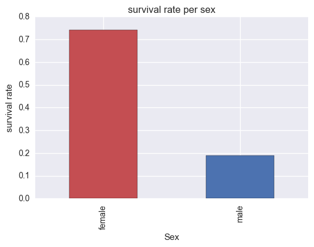

```python
sns.set_color_codes()
survival_rate_per_sex=titanic_adjust_df.groupby('Sex')['Survived'].mean()
print survival_rate_per_sex

ax=survival_rate_per_sex.plot(x='sex', y='survival rate', kind='bar', legend=False, color=['r','b'], title='survival rate per sex')
ax.set_ylabel('survival rate')

plt.show()
```

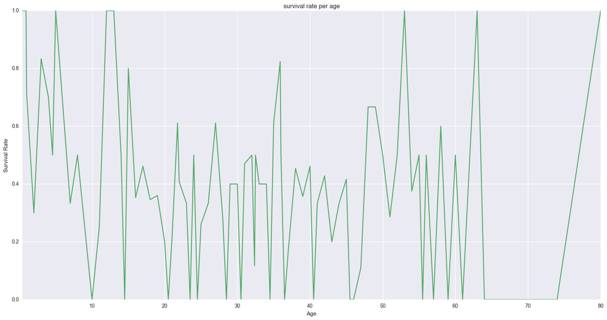

```python
my_plot = titanic_adjust_df.groupby('Age')['Survived'].mean().plot(legend=None,title="survival rate per age", color='g', figsize=(20,10))
my_plot.set_xlabel("Age")
my_plot.set_ylabel("Survival Rate")
```

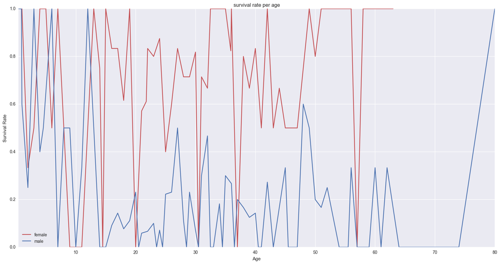

```python
my_plot = titanic_adjust_df[(titanic_adjust_df['Sex'] == 'female')].groupby('Age')['Survived'].mean().plot(legend=True, label='female', title="survival rate per age", color='r', figsize=(20,10))
my_plot2 = titanic_adjust_df[(titanic_adjust_df['Sex'] == 'male')].groupby('Age')['Survived'].mean().plot(legend=True, label='male',title="survival rate per age", color='b', figsize=(20,10))
my_plot.set_xlabel("Age")
my_plot.set_ylabel("Survival Rate")
```

My conclusion is that there is a clear difference in survival rate both in terms of sex and of age; Females and younger passengers have larger survival rates. The last graph clearly shows that around the age of 15 there is a significant change in the survival rate of males. Based on this is seems likely that the principle of 'Women and children first' was followed during evacuation.

To determine the group of women and children better I want to zoom in at the survival rates of males around the age of 15 and also check if the title Master is a good definition of a male child by comparing the survival rate of passengers with the title Master to those with the title Mr.

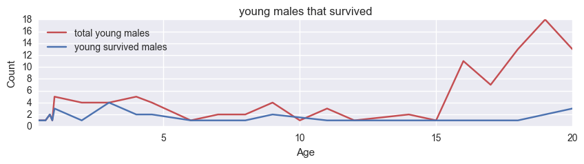

```python
# plotting total (blue) and survived (green) male passengers between 0 and 20 years of age

young_males_df=titanic_adjust_df[(titanic_adjust_df['Age']>=[0.0])&(titanic_adjust_df['Age']<=[20.0])&(titanic_adjust_df['Sex']=='male')]
young_males_df_survived=young_males_df[young_males_df['Survived']==1]

my_plot = young_males_df.groupby(['Age']).count()['PassengerId'].plot(legend=True, label='total young males', title="young males that survived", color='r',  figsize=(10,2))
my_plot2 = young_males_df_survived.groupby(['Age']).count()['PassengerId'].plot(legend=True, label='young survived males', title="young males that survived", color='b', figsize=(10,2))
my_plot.set_xlabel("Age")
my_plot.set_ylabel("Count")
```

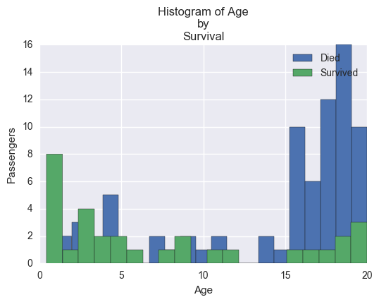

```python
# Histogram between the ages of 0 and 20 comparing not survived versus survived
#young_males_df.hist(column="Age",by=["Survival"],bins=20)
young_males_df.groupby('Survived')['Age'].get_group(0).hist(label = 'Died', bins = 20)
young_males_df.groupby('Survived')['Age'].get_group(1).hist(label = 'Survived', bins = 20)
plt.legend()
plt.title('Histogram of Age\nby\nSurvival')
plt.xlabel('Age')
plt.ylabel('Passengers')
```

As seen before, the age boundary for the Masters title is at 12 years old. In the two plots I see a a different trend around the age of 15, but the plots are not clear enough. The relative survival rate on the right side of the plot is much lower. The histograms show more detail. No children in the ages of 13, 14 and 15 survived, two children in the age of 14 died and one in the age of 15 died. Based on this, I conclude that the Master title is a good discriminator to describes the group of male children that were considered children in the sentence 'Women and children first'.

The next step is to split the population in two groups and compare these groups. The first group consists of all females plus the males that carry the Master title. The second group are all the males minus the males that carry the Master title. For both groups I want to compare the survival rate per value in the Parch field. During exploration I found out that the Parch field can contain the values 0, 1, 2, 3, 4, 5 and 6.

```python
# splitting passengers in two groups: women_and_children and adult_males

adult_males_df=titanic_adjust_df[(titanic_adjust_df['Title'] != 'Master') & (titanic_adjust_df['Sex'] == 'male')]
women_and_children_df=titanic_adjust_df[(titanic_adjust_df['Title'] == 'Master') | (titanic_adjust_df['Sex'] == 'female')]

print 'all data per number of parents and/or children'
print
print 'adult males survival mean'
adult_males_survival_mean_per_parch=adult_males_df.groupby(['Parch'])['Survived'].mean()
#adult_males_survival_mean_per_parch.rename(columns={'Survived':'Survival_Rate_Adult_Men'})
print adult_males_survival_mean_per_parch
print 'women and children survival mean'
women_and_children_survival_mean_per_parch=women_and_children_df.groupby(['Parch'])['Survived'].mean()
#women_and_children_survival_mean_per_parch.columns = ['Parch', 'Survival Rate Women and Children']
print women_and_children_survival_mean_per_parch
print 'number of adult males'
print adult_males_df.groupby(['Parch'])['Survived'].count()
print 'number of women and children'
print women_and_children_df.groupby(['Parch'])['Survived'].count()
```

```
all data per number of parents and/or children

adult males survival mean
Parch
0    0.163561
1    0.142857
2    0.133333
3    0.000000
4    0.000000
5    0.000000
Name: Survived, dtype: float64
women and children survival mean
Parch
0    0.789744
1    0.722892
2    0.584615
3    0.750000
4    0.000000
5    0.250000
6    0.000000
Name: Survived, dtype: float64
number of adult males
Parch
0    483
1     35
2     15
3      1
4      2
5      1
Name: Survived, dtype: int64
number of women and children
Parch
0    195
1     83
2     65
3      4
4      2
5      4
6      1
Name: Survived, dtype: int64
```

# Conclusion phase

Question 1: What is the influence of the size of the family (in terms of the column 'Parch') on the survival rate of a person. I also want to see how this is impacted by age and sex; what has been the effect of 'Women and Children' first to the survival rates in general and was this different for families?

I come to the following conclusions:

## Limitations of the analysis

Of only 714 from the 891 passengers the age was known. The unknown ages were determined based on the averages of the title carried by the passenger. This could have an impact on the survival rates per age plot. It could well be that the principle 'Women, children and elderly' was followed. Of this we cannot be sure, elderly with unkwown age are now counted as average age.

Since correlation is not proven with a t-test, we are not sure if the results are by change or not.

What would have been interesting data, is more detailed information on relationships between the passengers. Knowing which passengers all belong to the same group allows to examine group behaviour. This can not be done based on count of number of parents/children. Maybe this information could have been subtracted during wrangling, but I did not examine this.

# Communication phase

I wanted to know if the survival rate of a passenger on the Titanic was different based on the number of parents and /or children of these passengers. Because there the rule 'Women and children first' was applied on board of the Titanic, I compared the survival rates for women and children on the one hand and adult males on the other hand. Both groups exclude one another and both groups together form the complete population for which data was available.

The results are shown in the two histograms below.

The conclusion therefore is that there is a negative correlation between survival rate and the number of parents and/or children per passenger.

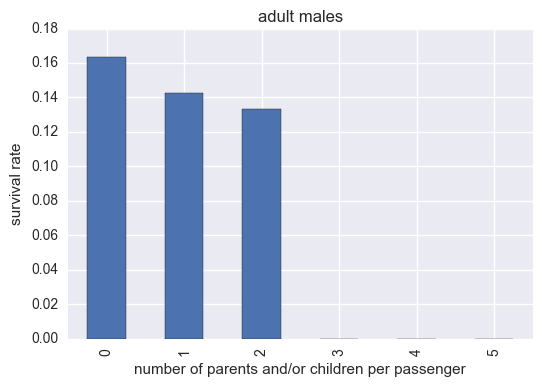

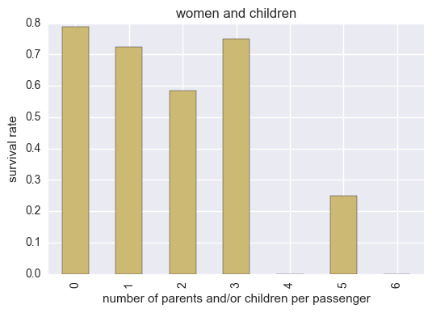

```python
# Histogram between the ages of 0 and 20 comparing not survived versus survived
ax=adult_males_survival_mean_per_parch.plot(x='Parch', y='survival rate', kind='bar', legend=False, color=('b'), title='adult males')
ax.set_ylabel('survival rate')
ax.set_xlabel('number of parents and/or children per passenger')
plt.show()
bx=women_and_children_survival_mean_per_parch.plot(x='Parch', kind='bar', legend=False, color=('y'), title='women and children')
bx.set_ylabel('survival rate')
bx.set_xlabel('number of parents and/or children per passenger')
plt.show()
```